# MorphoRegions

## Intrapsecific variability

To account for variability within a species or group, it is possible to **run the regionalization analysis on multiple specimens in a single analysis**. The `porpoise` dataset contains data of 3 different specimens of harbor porpoise.

```r
data("porpoise")
```

|  | Elements | Variables |
| --- | --- | --- |
| Porpoise 1 | 58 | 17 |
| Porpoise 2 | 56 | 17 |
| Porpoise 3 | 59 | 17 |

The total number of elements (vertebrae) can differ among specimens, but the number of variables and their order must be the same. The highest number of elements is used to generate the vertebral map. In the porpoise dataset, the first specimen has 58 post-cervical vertebrae, the second has 56, and the third one has 59, but they all have 17 variables. In the case of differing number of elements, homologous elements (vertebrae) must be identified by the same number in the positional information column of the data.

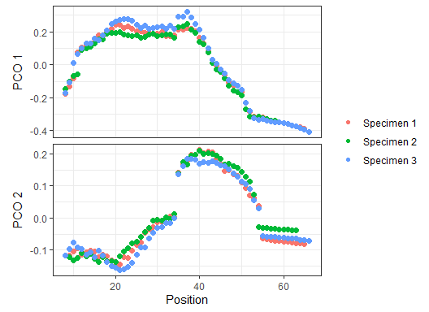

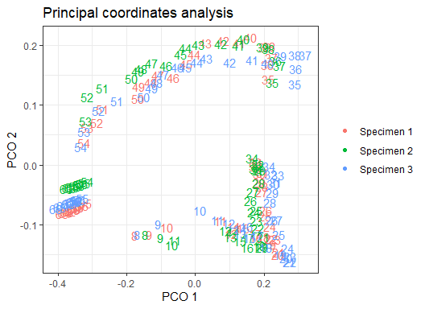

**Fig.15.** PCO plots of the three specimens of harbor porpoise.

```r
# Process measurements data
porpoise_data <- process_measurements(list(porpoise1, porpoise2, porpoise3), pos = "Vertebra")

# Compute PCOs
porpoise_pco <- svdPCO(porpoise_data, "gower")

# Plot PCOs
plot(porpoise_pco, 1:2)
plot(porpoise_pco, pco_x = 1, pco_y = 2)
```

Once data of each specimen have been supplied to the `process_measurements` function, **the process to run the analysis is similar to running the analysis on a single specimen at a time**.

```r
# Calculate number of PCOs to use in subsequent analyses
PCOs <- PCOselect(porpoise_pco, "variance", cutoff = .05)

# Performance for all models across all breakpoint combos
regionresults <- calcregions(porpoise_pco, scores = PCOs,
                             noregions = 3, verbose = FALSE)

# Adding more models to existing results
regionresults <- addregions(regionresults, noregions = 4:5,
                            exhaus = FALSE, verbose = FALSE)

# Select best model
models <- modelselect(regionresults)
supp <- modelsupport(models)
supp
```

```
#> - Model support (AICc)
#>  Regions BP 1 BP 2 BP 3 BP 4 sumRSS      AICc deltaAIC model_lik Ak_weight
#>        5   18   33   38   53  0.105 -2769.304    0.000         1         1
#>        4   20   40   52    .  0.148 -2656.161  113.142         0         0
#>        3   21   39    .    .  0.293 -2426.584  342.720         0         0
#>        2   37    .    .    .  0.631 -2167.924  601.380         0         0
#>        1    .    .    .    .  2.155 -1749.033 1020.271         0         0
#> Region score: 5
#>
#> - Model support (BIC)
#>  Regions BP 1 BP 2 BP 3 BP 4 sumRSS       BIC deltaBIC model_lik BIC_weight
#>        5   18   33   38   53  0.105 -2709.414    0.000         1          1
#>        4   20   40   52    .  0.148 -2607.254  102.160         0          0
#>        3   21   39    .    .  0.293 -2388.776  320.638         0          0
#>        2   37    .    .    .  0.631 -2141.330  568.084         0          0
#>        1    .    .    .    .  2.155 -1733.764  975.650         0          0
#> Region score: 5
```

```r
# Calculate variability of optimal breakpoints
bpvar <- calcBPvar(regionresults, noregions = 5, pct = .05,
                   criterion = "bic")
bpvar
```

```
#>         BP 1   BP 2   BP 3   BP 4
#> wMean 18.014 33.124 37.695 52.655
#> wSD    0.651  0.510  0.461  0.493
#> - Computed using top 4.57% of models
```

```r
# Calculate model performance (R2) of best model
modelperf(porpoise_pco, scores = PCOs, modelsupport = supp,
          criterion = "bic", model = 1)
```

```
#> Breakpoints: 18, 33, 38, 53
#>
#> - Univariate:
#>          R² Adj. R²
#> PCO.1 0.984   0.983
#> PCO.2 0.936   0.935
#>
#> - Multivariate:
#>      R² Adj. R²
#>   0.974   0.974
```

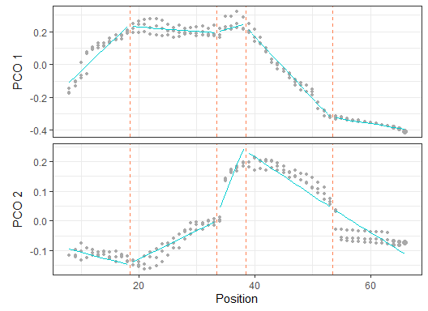

**Fig.16.** Best fit model (based on BIC) on PCO 1 and 2 calculated on the three harbor porpoise specimens.

```r
# Plot PCOs of best fit model
plotsegreg(porpoise_pco, scores = 1:2, modelsupport = supp,
            criterion = "bic", model = 1)
```

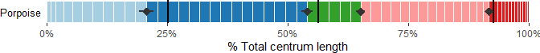

**Fig.17.** Vertebral map of best fit model (including variance in breakpoint position) based on the three harbor porpoise specimens.

```r
# Plot vertebral map of best fit model
plotvertmap(porpoise_pco, name = "Porpoise",
            type = "percent", centraL = "Lc",
            reg.lim = c(20, 34, 54), dropNA = TRUE,
            bpvar = bpvar, sd.col = "grey20")
```

## Other useful options

### Fit a specific model

Instead of fitting all possible models for a given range of region number, `calcmodel()` allows one to fit a single model with user-defined breakpoint positions.

```r
#Fit a single breakpoints model
regionsmodel <- calcmodel(dolphin_pco, scores = 1:3, cont = TRUE,
                          bps = c(19, 24, 27, 32, 35, 38, 41))
regionsmodel
```

```
#>  Regions BP 1 BP 2 BP 3 BP 4 BP 5 BP 6 BP 7 sumRSS RSS.1 RSS.2 RSS.3
#>        8   19   24   27   32   35   38   41  0.034  0.01  0.01 0.013
#>
#> - Support:
#>      AICc       BIC
#> -885.1162 -818.3415
```

```r
#Evaluate performance (R2) on that model
modelperf(regionsmodel)
```

```
#> Breakpoints: 19, 24, 27, 32, 35, 38, 41
#>
#> - Univariate:
#>          R² Adj. R²
#> PCO.1 0.996   0.995
#> PCO.2 0.983   0.978
#> PCO.3 0.904   0.879
#>
#> - Multivariate:
#>      R² Adj. R²
#>   0.990   0.987
```

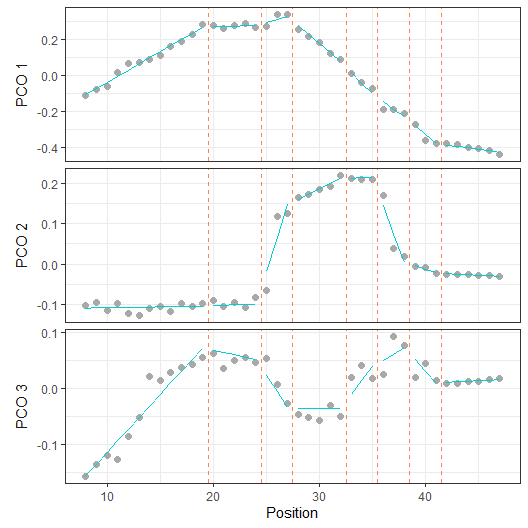

**Fig.18.** Best fit segmented linear regression model on PCO 1-3 when forcing breakpoint position at vertebrae 19, 24, 27, 32, 35, 38, and 41.

```r
#Plot model results:
plotsegreg(regionsmodel, scores = 1:3)
```

### Subsampling elements

For specimens with numerous elements (more than 100), computational time can become high. It can then be useful to run the regionalization analysis on a subset of elements If the analyses are run in a comparative framework and there is substantial variation of the number of elements across specimens, it is also advised to subsample elements to a constant number of elements for all specimens.

`subsample()` allows one to subsample elements either by providing the number of elements to retain or the proportion of total elements to retain.

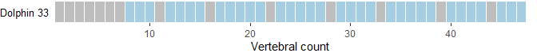

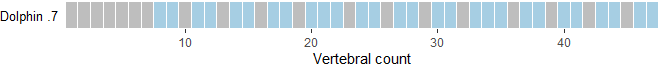

**Fig.19.** Vertebral map of dolphin dataset with 33 subsampled vetrebrae *(top)* and 70% of total vertebrae subsampled *(bottom)*. Vertebrae dropped are in grey and vertebrae retained are in blue shade*.

```r
# Retain 33 vertebrae
dolphin_pco_sub.33 <- subsample(dolphin_pco, sample = 33)

# Retain 70% of initial number of vertebrae
dolphin_pco_sub.7 <- subsample(dolphin_pco, sample = .7)

plotvertmap(dolphin_pco_sub.33, name = "Dolphin 33")
plotvertmap(dolphin_pco_sub.7, name = "Dolphin .7")
```

By default, elements to drop will be selected to be equidistant along the structure (rounded to integers). A random subsampling of elements along the structure can be applied by supplying `type = "random"` to `subsample()`.

### Simulating data

`simregions()` allows one to simulate datasets that satisfy some user-defined constraints such as number of elements, regions, PCO axes, minimum number of elements per region, variance around the linear fits, and difference in slope between successive linear segments.

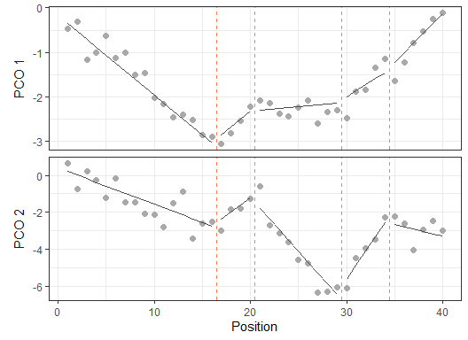

**Fig.20.** Plot on PCO 1 and 2 of the **simulated dataset** with 40 vertebrae and 5 regions (4 breakpoints).

```r
# Simulate data
set.seed(2024)
sim <- simregions(nvert = 40, nregions = 5, nvar = 4, r2 = .92,
                  minvert = 3, cont = TRUE)

# Plot:
plot(sim, scores = 1:2)
```

The regionalization analysis can then be run on the simulated dataset.

```r
simresults <- calcregions(sim, scores = 1:4, noregions = 6, verbose = FALSE)

simmodels <- modelselect(simresults)
simmodels
```

```
#>  Regions BP 1 BP 2 BP 3 BP 4 BP 5  sumRSS  RSS.1  RSS.2  RSS.3   RSS.4
#>        1    .    .    .    .    . 239.092 26.450 72.184 28.139 112.318
#>        2   29    .    .    .    . 185.535  8.393 39.551 26.728 110.863
#>        3   19   28    .    .    . 148.383  4.114 31.513 22.545  90.211
#>        4   20   28   34    .    . 128.804  4.623 23.291  9.623  91.267
#>        5   15   21   28   34    . 109.794  1.835 11.249  9.891  86.820
#>        6    4   15   21   28   34 105.817  1.724 11.209  7.410  85.474
```

```r
simsupport <- modelsupport(simmodels)
simsupport
```

```
#> - Model support (AICc)
#>  Regions BP 1 BP 2 BP 3 BP 4 BP 5  sumRSS   AICc deltaAIC model_lik Ak_weight
#>        5   15   21   28   34    . 109.794  8.147    0.000     1.000     0.988
#>        6    4   15   21   28   34 105.817 17.655    9.508     0.009     0.009
#>        4   20   28   34    .    . 128.804 19.417   11.270     0.004     0.004
#>        3   19   28    .    .    . 148.383 28.790   20.644     0.000     0.000
#>        2   29    .    .    .    . 185.535 52.184   44.037     0.000     0.000
#>        1    .    .    .    .    . 239.092 81.221   73.075     0.000     0.000
#> Region score: 5
#>
#> - Model support (BIC)
#>  Regions BP 1 BP 2 BP 3 BP 4 BP 5  sumRSS     BIC deltaBIC model_lik BIC_weight
#>        3   19   28    .    .    . 148.383  79.292    0.000     1.000      0.650
#>        5   15   21   28   34    . 109.794  81.855    2.562     0.278      0.181
#>        4   20   28   34    .    . 128.804  82.028    2.736     0.255      0.166
#>        2   29    .    .    .    . 185.535  89.668   10.376     0.006      0.004
#>        6    4   15   21   28   34 105.817 101.326   22.034     0.000      0.000
#>        1    .    .    .    .    . 239.092 104.869   25.577     0.000      0.000
#> Region score: 3.52
```

```r
modelperf(sim, modelsupport = simsupport, criterion = "aic", model = 1)
```

```
#> Breakpoints: 15, 21, 28, 34
#>
#> - Univariate:
#>          R² Adj. R²
#> PCO.1 0.931   0.921
#> PCO.2 0.907   0.894
#> PCO.3 0.883   0.866
#> PCO.4 0.884   0.867
#>
#> - Multivariate:
#>      R² Adj. R²
#>   0.888   0.872
```

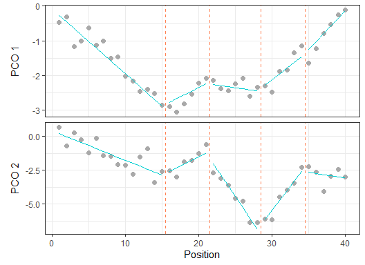

**Fig.21.** Plot on PCO 1 and 2 of the **recovered best fit** on regionalization analysis ran on the simulated dataset.

```r
#Plot best model fit
plotsegreg(sim, scores = 1:2, modelsupport = simsupport,
            criterion = "aic", model = 1)
```

The simulated dataset had 5 predefined regions with breakpoints at vertebrae 16, 20, 29, and 34. When running the regionalization analysis on the simulated dataset, the analysis correctly recovered the 5 regions model as the best fit model using AICc, however the 5 regions model is second best using BIC.

The AICc best fit model recovered breakpoints at vertebrae 15, 21, 28, 34. The recovered position of the first three breakpoints differ sightly from the simulated positions, and the recovered position of the fourth breakpoint matches that of the simulated data.

```r
# Simulated data breakpoints:
sim$BPs
```

```
#> breakpoint1 breakpoint2 breakpoint3 breakpoint4
#>          16          20          29          34
```

```r
# Recovered best fit breakpoints:
simsupport$Model_support[1,2:5]
```

```
#>       breakpoint1 breakpoint2 breakpoint3 breakpoint4
#> 26746          15          21          28          34
```

```r
# Variability of recovered best fit breakpoints:
calcBPvar(simresults, noregions = 5, pct = 0.1, criterion = "aic")
```

```
#>         BP 1   BP 2   BP 3   BP 4
#> wMean 15.184 20.652 28.138 34.249
#> wSD    1.618  0.788  0.511  0.710
#> - Computed using top 10% of models
```

## References

Gillet, A., B. Frédérich, S. E. Pierce, and E. Parmentier. 2022. “Iterative Habitat Transitions Are Associated with Morphological Convergence of the Backbone in Delphinoids.” *Journal of Mammalian Evolution* 29: 931–46. https://doi.org/10.1007/s10914-022-09615-7.

Gillet, A., K. E. Jones, and S. E. Pierce. Under Review. “Repatterning of Mammalian Backbone Regionalization in Cetaceans,” Under Review.

Head, J. J., and P. D. Polly. 2015. “Evolution of the Snake Body Form Reveals Homoplasy in Amniote Hox Gene Function.” *Nature* 520: 86–89. https://doi.org/10.1038/nature14042.

Jones, K. E., K. D. Angielczyk, P. D. Polly, J. J. Head, V. Fernandez, J. K. Lungmus, S. Tulga, and S. E. Pierce. 2018. “Fossils Reveal the Complex Evolutionary History of the Mammalian Regionalized Spine.” *Science* 361: 1249–52. https://doi.org/10.1126/science.aar3126.